# Lab3

Melissa Widas

2024-04-17

### Assignment Lab 3:

Due next week: April 23 at 11:59PM

For this assignment you’ll use the article data you downloaded from Nexis Uni in Week 2.

```r
library(quanteda)
library(tm)
library(topicmodels)
library(ldatuning)
library(tidyverse)
library(tidytext)
library(reshape2)
library(here)
library(LexisNexisTools)
library(dplyr)
library(readr)
library(stringr)
library(tidyr) #pivot_wider()
library(ggplot2)
```

1. Create a corpus from your articles.

```r
# load in data
# NEXIS terms were mine reclamation
setwd(here("data/mine_reclamation_files")) #where the .docxs live
mine_files <- list.files(pattern = ".docx", path = getwd(),
                      full.names = TRUE, recursive = TRUE, ignore.case = TRUE)

dat_mine <- lnt_read(mine_files, convert_date = FALSE, remove_cover = FALSE)

meta_df <- dat_mine@meta
articles_df <- dat_mine@articles
paragraphs_df <- dat_mine@paragraphs

dat2 <- tibble(Date = meta_df$Date,
               Headline = meta_df$Headline,
               id = articles_df$ID,
               text = articles_df$Article)
```

```r
# create the corpus
corpus <- corpus(x = dat2, text_field = "text")
```

2. Clean the data as appropriate.

```r
# remove stop words
add_stops <- stopwords(kind = quanteda_options("language_stopwords"))

tokens(corpus)
```

```
## Tokens consisting of 99 documents and 3 docvars.
## text1 :
##  [1] "WASHINGTON" ","          "Feb"        "."          "23"
##  [6] "-"          "-"          "The"        "U.S"        "."
## [11] "Department" "of"
## [ ... and 299 more ]
##
## text2 :
##  [1] "The"         "following"   "information" "was"         "released"
##  [6] "by"          "the"         "Bureau"      "of"          "Land"
## [11] "Management"  ":"
## [ ... and 335 more ]
##
## text3 :
##  [1] "Appalachian" "Voices"      "issued"      "the"         "following"
##  [6] "news"        "release"     "on"          "Oct"         "."
## [11] "19"          ","
## [ ... and 1,039 more ]
##
## text4 :
##  [1] "Rep"       "."         "Pete"      "Stauber"   ","         "Minnesota"
##  [7] ","         "chairman"  "of"        "the"       "House"     "Natural"
## [ ... and 474 more ]
##
## text5 :
##  [1] "The"             "following"       "information"     "was"
##  [5] "released"        "by"              "the"             "U.S"
##  [9] "."               "House"           "of"              "Representatives"
## [ ... and 426 more ]
##
## text6 :
##  [1] "WASHINGTON" ","          "DC"         ","          "April"
##  [6] "29"         "-"          "-"          "The"        "U.S"
## [11] "."          "Department"
## [ ... and 326 more ]
##
## [ reached max_ndoc ... 93 more documents ]
```

```r
# remove punctuation, numbers, and url
toks <- tokens(corpus, remove_punct = T, remove_numbers = T, remove_url = T, remove_symbols = T)

tok1 <- tokens_select(toks, pattern = add_stops, selection = "remove")

# make everything lowercase
dfm1 <- dfm(tok1, tolower = T)
# trimming out things that appear only once in the text
dfm2 <- dfm_trim(dfm1, min_docfreq = 2)

# keep rows where the sum across the row is greater than 0
# not very relevant in this case but if you had a tweet or something fully character driven it would catch these
sel_idx <- slam::row_sums(dfm2) > 0
dfm <- dfm2[sel_idx,]
```

3. Run three models (i.e. with 3 values of k) and select the overall best value for k (the number of topics) - include some justification for your selection: theory, FindTopicsNumber() optimization metrics, interpretability, LDAvis. Select the best single value of k.

```r
k3 <- 3

topicModel_k3 <- LDA(dfm,
                     k3,
                     method = "Gibbs",
                     # 1000 is a rule of thumb, but you might need to adjust depending on data
                     control = list(iter = 1000),
                     verbose = 25)

result3 <- posterior(topicModel_k3)

results <- FindTopicsNumber(dfm,
                            topics = seq(from = 2,
                                         to = 20,
                                         by = 1),
                            metrics = c("CaoJuan2009", "Deveaud2014"),
                            method = "Gibbs",
                            verbose = T)
```

```
## fit models... done.
## calculate metrics:
##   CaoJuan2009... done.
##   Deveaud2014... done.
```

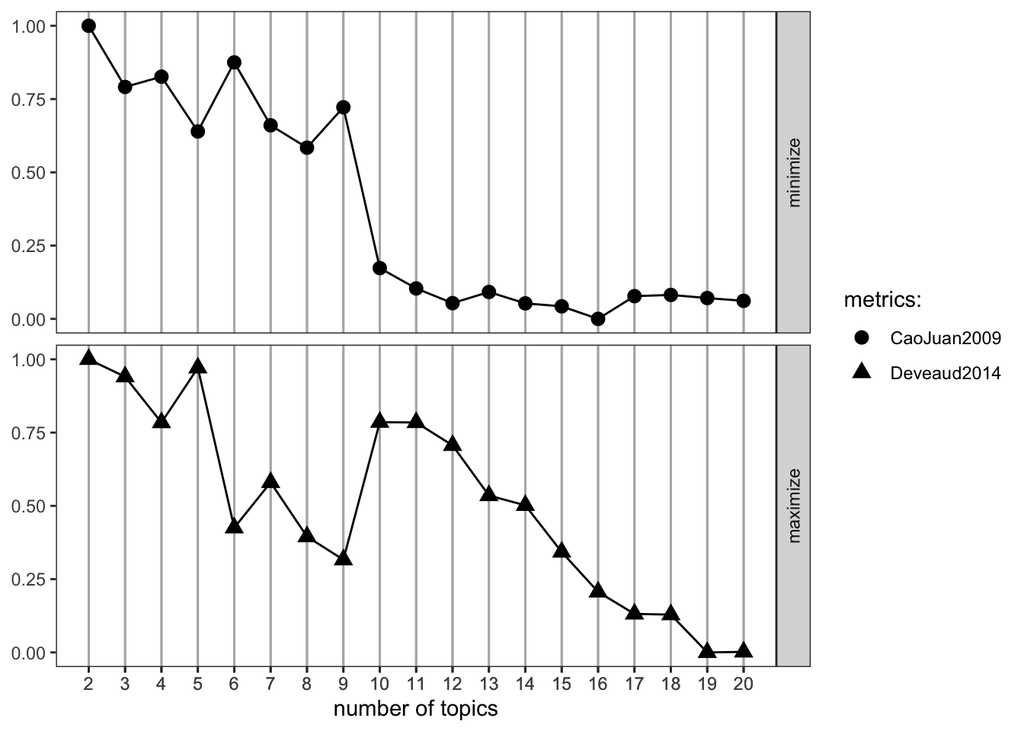

```r
FindTopicsNumber_plot(results)
```

```r
k8 <- 8

topicModel_k8 <- LDA(dfm,
                     k8,
                     method = "Gibbs",
                     # 1000 is a rule of thumb, but you might need to adjust depending on data
                     control = list(iter = 1000),
                     verbose = 25)

result8 <- posterior(topicModel_k8)
```

```r
k10 <- 10

topicModel_k10 <- LDA(dfm,
                     k10,
                     method = "Gibbs",
                     # 1000 is a rule of thumb, but you might need to adjust depending on data
                     control = list(iter = 1000),
                     verbose = 25)

result10 <- posterior(topicModel_k10)
```

4. Plot the top terms in each topic and the distribution of topics across a sample of the documents (constrained by what looks good in the plot).

```r
# distribution of topics in documents
theta <- result8$topics
# distribution of terms in topic
beta <- result8$terms
vocab <- colnames(beta)

topics <- tidy(topicModel_k8, matrix = "beta")

top_terms <- topics |>
  group_by(topic) |>
  top_n(10, beta) |>
  ungroup() |>
  arrange(topic, -beta)

top_terms
```

```
## # A tibble: 81 × 3
##    topic term          beta
##    <int> <chr>        <dbl>
##  1     1 information 0.0557
##  2     1 collection  0.0338
##  3     1 public      0.0252
##  4     1 number      0.0238
##  5     1 comment     0.0198
##  6     1 comments    0.0173
##  7     1 burden      0.0137
##  8     1 including   0.0135
##  9     1 estimated   0.0135
## 10     1 agency      0.0131
## # ℹ 71 more rows
```

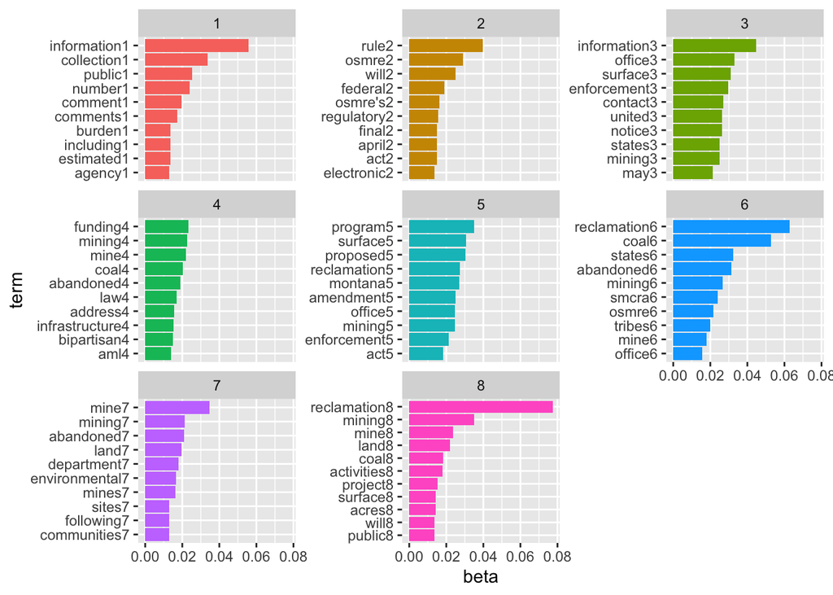

```r
top_terms |>
  mutate(term = reorder_within(term, beta, topic, sep = "")) |>
  ggplot(aes(term, beta, fill = factor(topic))) +
  geom_col(show.legend = F) +
  facet_wrap(~topic, scales = "free_y") +
  scale_x_reordered() +
  coord_flip()
```

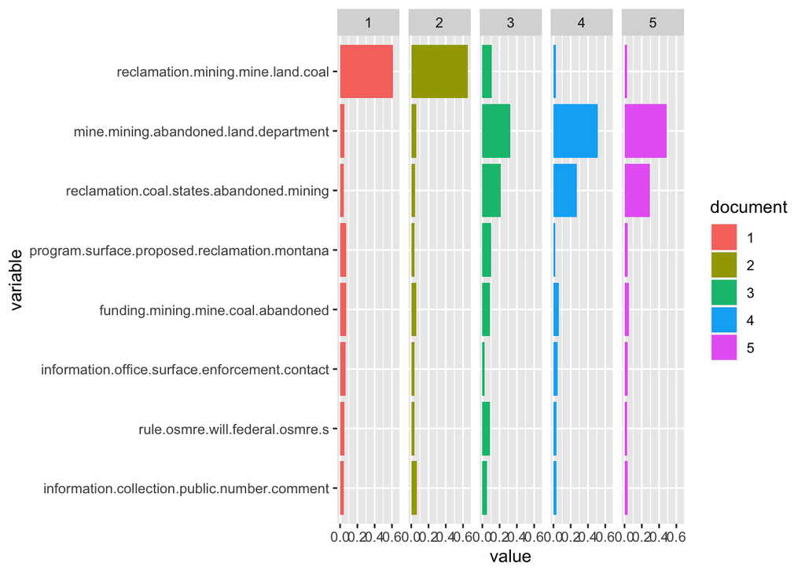

```r
topic_words <- terms(topicModel_k8, 5)
topic_names <- apply(topic_words, 2, paste, collapse = " ")

#specify # of examples to inspect
example_ids <- c(1:5)
n <- length(example_ids)

# get topic proportions from example documents
example_props <- theta[example_ids,]
colnames(example_props) <- topic_names

#combine example topics with identifiers and melt to plotting form
viz_df <- melt(cbind(data.frame(example_props),
                     document = factor(1:n),
                     variable.name = "topic",
                     id.vars = "document"))
ggplot(data = viz_df, aes(variable, value, fill = document), ylab = "proportion") +
  geom_bar(stat = "identity") +
  coord_flip() +
  facet_wrap(~document, ncol = n)
```

5. Take a stab at interpreting the resulting topics. What are the key themes discussed in the articles in your data base?

**The key themes discussed in the articles in my database are environmental effects of mining, the office of surface mining and reclamation, federal laws regarding mining, mining on tribal land, public reaction to mining, how information regarding mining is relayed, and federal amendments. Overall these key themes indicate federal involvement with mining and its impacts on the surrounding environment.**